# Words, Words, Words

AKA How To Talk Like A Philosopher

#### This is a guidebook aiming to get an idea which words are the most philisophical, or at the very least to explore which words are most used in philosophy.

#### The data used in this report can be found at https://www.kaggle.com/kouroshalizadeh/history-of-philosophy

This report is prepared with the following environmental settings.

```
               _
platform       x86_64-w64-mingw32
arch           x86_64
os             mingw32
system         x86_64, mingw32
status
major          4
minor          1.0
year           2021
month          05
day            18
svn rev        80317
language       R
version.string R version 4.1.0 (2021-05-18)
nickname       Camp Pontanezen
```

### Where to start?

The data in it’s original form wasn’t quite ready to be used for this analysis. In order to analyze the data, I split the tokenized_txt column into it’s components (i.e. I gave each word it’s own row), and grouped them by word and author to figure out how many times each word was used individually.

# Which words were used most by philsophers?

This is a question that can be looked at two ways:

- Which words are used most throughout all of these philosophical works?
- Which words did each philosopher use most?

## What words are most used overall?

In this case, I’ve chosen to show the frequencies of the top 15 most used words in these philosophical works in a wordmap and barplot below.

[interactive chart not shown]

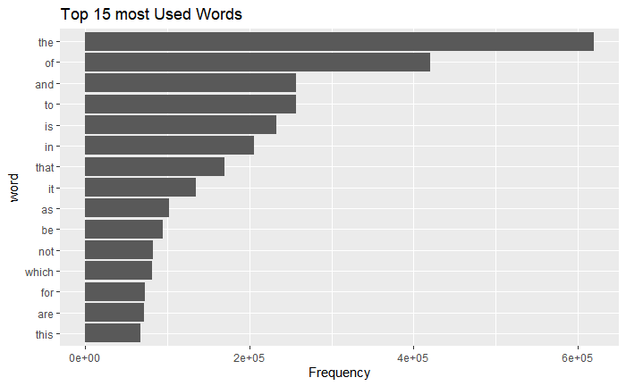

As you can see “the” is the most used word by a very large margin. We can see that the words used most by these philosophers are small words that have no large meaning by themselves. It may be impossible to string all 15 of these words together in a sentence, they are vague and lack any real substance to grab on to. The closest I could get was “Be as it is, which are not this or for that.” This may either mean that philosophers are very vague or they switch topics so rapidly that no one subject name is brought up too much. Either way, this leads me to believe that the language used in philosophy may be hard to decipher.

## But are the authors using different words?

We have data on 36 different authors, but lets start by grabbing a few of them to see if they match and go from there. If the first few don’t have an identical distribution of word use then it’s fair to say that the whole group isn’t likely to have identical word choice either. Lets focus on the 6 that we have the most data from.

| author | Total_Words |
| --- | --- |
| Aristotle | 1342094 |
| Plato | 794931 |
| Hegel | 660355 |
| Foucault | 474609 |
| Kant | 462209 |
| Malebranche | 375979 |

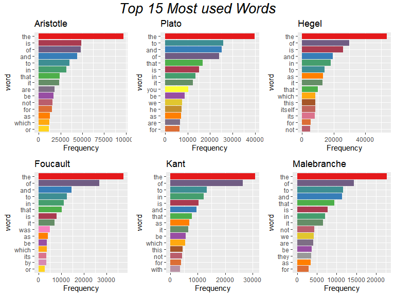

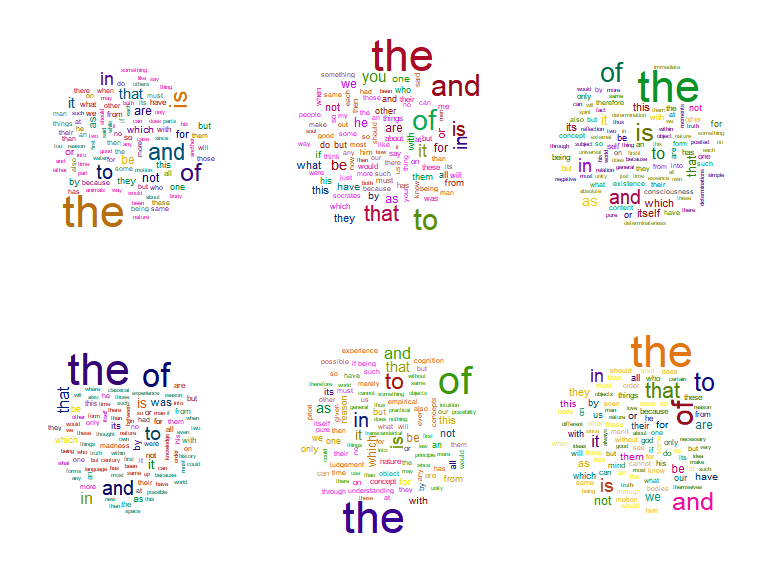

These wordclouds of the 6 chosen philosophers confirm what we learned from the barplot. Word choice seems unique to the philosopher but all of them have a tendency to favor short words that tie together larger concepts. In the wordmaps we can get an idea of what longer words come up, when they do come up. We see that the longer words are ones such as “Socrates”, “understanding”, “possible”, “consciousness”, “therefore”, “thought”, and “because.” As one might expect, the long words are mostly about thinking and the concepts of human thought and emotion. It’s also noteworthy to point out that Kant favors long words way more than the other 5 philosophers we chose to look more closely at, Hegel and Malebranche also use a fair amount of moderately sized words. However, Plato and to some degree Aristotle have an extremely clear habit of primarily compromising their works of smaller words. The longest word in Plato’s top 100 most used words is “something,” which is only 9 letters long.

# Are shorter words more philisophical?

Since the words we saw were used most often were quite short, does that mean if I use smaller words will I sound philosophical?

Well, the average number of character used per word in total for all the philosophical words is 5.67. Since you can’t use half a letter in a word, we’ll say that the average word is about 6 letters long. You may be thinking something along the lines of “But all of the most-used words were really small, how can this be?” and you would have a very valid point. To explain why this is, lets look at the overall distribution of how many characters were in each word.

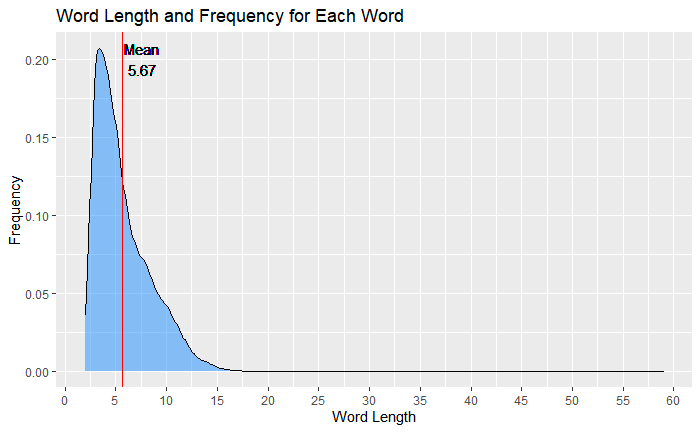

This isn’t looking too good, there are a couple of words here with 50+ letters, that’s impossible! The longest word I could find in the dictionary is “pneumonoultramicroscopicsilicovolcanoconiosis” and it only has 45 letters, so how do we have entries that are so long?

You see, the long entries here are multiple words that were published without spaces between them and weird long strings of letters that were included in addition to the readable literature. Take a look at the ten longest entries below:

| word | word_length |
| --- | --- |
| individualityhasbeenshatteredintoamultitudeofseparateatoms | 59 |
| lilillililillllllllllllllwlllllllullllllllulllllllulllw | 56 |
| ahovementionedexternalteleologicalrelatiqn | 43 |
| lllwllllllllllllllullllllllulllilll | 36 |
| onseemsceasesvatolidreonlyectduring | 36 |
| characterbftheparticularindividual | 35 |
| theancienrcgimeorreturningtoforms | 34 |
| puremoralityoutsideofitselfinto | 32 |
| conscioilsnessimmediatelymakes | 31 |
| samerespecttheopposlteofitselj | 31 |

Initially, I believed these to be errors in parsing but if you look at the sentences they come from in the dataset they appear in the same way. They do however appear most often in the works of a few philosophers, so lets look at the distribution of word length for all the different authors.

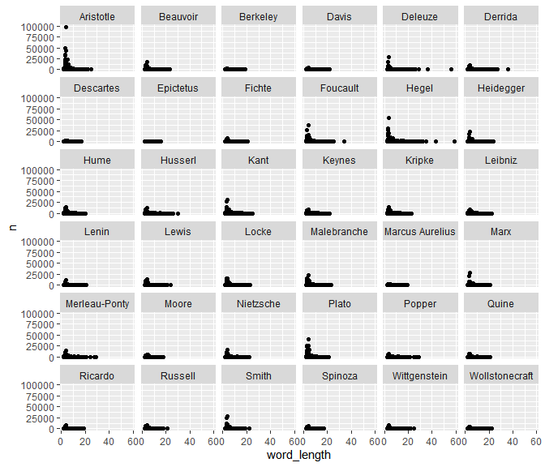

The longest of these run-ons and indecipherable strings come from works written by “Hegel”, “Derrida”, and “Deleuze”, but upon further investigation I found them in works by most of the authors we have information on. Let us suppose we decide to count these unusual strings as transcribing errors for now and not a unique form of self-expression used primarily by philosophers. Let’s remove the outliers in word length and see what happens!

Using the list of unique words as a dataset to calculate the appropriate word length, we find that the cutoff for outliers is 17 characters long, as illustrated in the boxplot below.

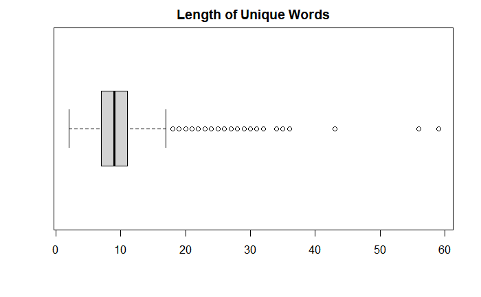

Removing all words longer than 17 characters long gives us the following distribution

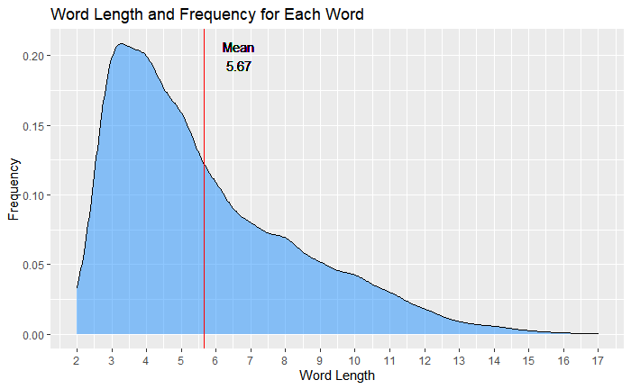

It looks like if you want to sound like a philosopher you should use mostly words that are 2-5 words long and sprinkle in a long word at least every ten words (or about 5-10% of your words should be long, or at least longer than 8 or 9 characters). Despite removing all the outliers, due to our large sample size the mean remains almost identical. The average length of the words continues to be around 6 characters long. This is not too surprising since we have 102,189 unique character combinations.

# Conclusion

Good luck! And don’t forget, whatever way you choose to speak be nice and others will be sure to listen!